# Geography 176A

Lab 03: COVID-19 Pandemic

[Stephanie Hurtado](https://github.com/shurtadogonzalez/shurtadogonzalez.github.io)

```r
url = 'https://raw.githubusercontent.com/nytimes/covid-19-data/master/us-counties.csv'
covid = read_csv(url)
```

# Question 1

```r
set_up = covid %>%
  filter(state == "California") %>%
  group_by(county) %>%
  mutate(NewCases = cases - lag(cases)) %>%
  mutate(Cumul_Cases = sum(cases)) %>%
  ungroup() %>%
  filter(date == max(date))
```

## Table representing the five counties in CA with the most new cases at the most current day

```r
(most_new_cases = set_up %>%
  slice_max(NewCases, n = 5) %>%
  select(county, NewCases))
```

```
## # A tibble: 5 x 2
##   county         NewCases
##   <chr>             <dbl>
## 1 Los Angeles         809
## 2 San Diego           265
## 3 Orange              185
## 4 Fresno              159
## 5 San Bernardino      156
```

```r
knitr::kable(most_new_cases,
             caption = "Most New Cases: California Counties",
             col.names = c("County", "New Cases"),
             format.args = list(big.mark = ",")) %>%
  kableExtra:: kable_styling("basic", full_width =  TRUE, font_size = NULL)
```

Most New Cases: California Counties

| County | New Cases |
| --- | --- |
| Los Angeles | 809 |
| San Diego | 265 |
| Orange | 185 |
| Fresno | 159 |
| San Bernardino | 156 |

## Table representing the five counties in CA with the most cumulative cases at the most current day

```r
(most_cumul_cases = set_up %>%
    slice_max(Cumul_Cases, n = 5) %>%
    select(county, Cumul_Cases))
```

```
## # A tibble: 5 x 2
##   county         Cumul_Cases
##   <chr>                <dbl>
## 1 Los Angeles       18408002
## 2 Riverside          3611739
## 3 Orange             3293539
## 4 San Bernardino     2972488
## 5 San Diego          2832227
```

```r
knitr::kable(most_cumul_cases,
             caption = "Most Cumulative Cases: California Counties",
             col.names = c("County", "Cumulative Cases"),
             format.args = list(big.mark = ",")) %>%
  kableExtra:: kable_styling("basic", full_width =  TRUE, font_size = NULL)
```

Most Cumulative Cases: California Counties

| County | Cumulative Cases |
| --- | --- |
| Los Angeles | 18,408,002 |
| Riverside | 3,611,739 |
| Orange | 3,293,539 |
| San Bernardino | 2,972,488 |
| San Diego | 2,832,227 |

## Adding population information

```r
PopulationEstimates <- read_excel("../data/PopulationEstimates.xls", skip = 2) %>%
  dplyr::select(fips = FIPStxt, state = State, county= Area_Name, pop_2019 = POP_ESTIMATE_2019)
```

```r
pop = PopulationEstimates %>%
  dplyr::right_join(covid, by = "fips") %>%
  dplyr::filter(state.y == "California") %>%
  dplyr::group_by(county.y) %>%
  mutate(cumul_cases_per_cap = sum(cases) / pop_2019) %>%
  mutate(new_cases_per_cap = ((cases - lag(cases)) /pop_2019)) %>%
  filter(date == max(date)) %>%
  ungroup()
```

## Table representing the five counties in CA with the most new cases per capita at the most current day

```r
(most_new_cases_per_cap = pop %>%
    slice_max(new_cases_per_cap, n = 5) %>%
    select(county.y, new_cases_per_cap))
```

```
## # A tibble: 5 x 2
##   county.y   new_cases_per_cap
##   <chr>                  <dbl>
## 1 Kings               0.000262
## 2 San Benito          0.000239
## 3 Monterey            0.000203
## 4 Lake                0.000171
## 5 Fresno              0.000159
```

```r
knitr::kable(most_new_cases_per_cap,
             caption = "Most New Cases Per Capita: California Counties",
             col.names = c("County", "New Cases Per Capita"),
             format.args = list(big.mark = ",")) %>%
  kableExtra:: kable_styling("basic", full_width =  TRUE, font_size = NULL)
```

Most New Cases Per Capita: California Counties

| County | New Cases Per Capita |
| --- | --- |
| Kings | 0.0002615 |
| San Benito | 0.0002388 |
| Monterey | 0.0002027 |
| Lake | 0.0001708 |
| Fresno | 0.0001591 |

## Table representing the five counties in CA with the most cumulative cases per capita at the most current day

```r
(most_cumul_per_cap = pop %>%
    slice_max(cumul_cases_per_cap, n = 5) %>%
    select(county.y, cumul_cases_per_cap))
```

```
## # A tibble: 5 x 2
##   county.y    cumul_cases_per_cap
##   <chr>                     <dbl>
## 1 Imperial                   4.80
## 2 Kings                      2.77
## 3 Tulare                     1.95
## 4 Kern                       1.84
## 5 Los Angeles                1.83
```

```r
knitr::kable(most_cumul_per_cap,
             caption = "Most Cumulative Cases Per Capita: California Counties",
             col.names = c("County", "Cumulative Cases Per Capita"),
             format.args = list(big.mark = ",")) %>%
  kableExtra:: kable_styling("basic", full_width =  TRUE, font_size = NULL)
```

Most Cumulative Cases Per Capita: California Counties

| County | Cumulative Cases Per Capita |
| --- | --- |
| Imperial | 4.795111 |
| Kings | 2.772264 |
| Tulare | 1.949337 |
| Kern | 1.844563 |
| Los Angeles | 1.833629 |

## Total number of new cases in the last 14 days per 100,000 people

```r
last_14_days = covid %>%
  right_join(PopulationEstimates, by = "fips") %>%
  filter(date >= max(date, na.rm = TRUE) - 13, state.x == "California") %>%
  group_by(county.x) %>%
  summarize(new_cases_per_cap = sum(cases - lag(cases), na.rm = TRUE) / (max(pop_2019) / 100000)) %>%
  filter(new_cases_per_cap <= 100) %>%
  ungroup()
```

# Question 2

## The number of daily new cases and the 7-day rolling mean of the California, New York, Florida, and Lousiana

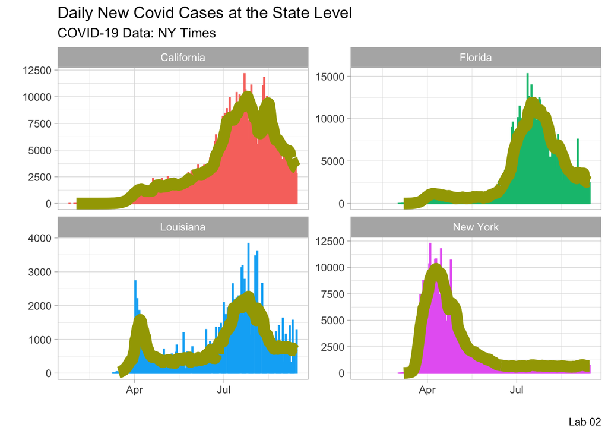

```r
four_states = covid %>%
  filter (state %in% c("California", "Louisiana", "New York", "Florida")) %>%
  group_by(state, date) %>%
  summarize(cases = sum(cases)) %>%
  ungroup() %>%
  group_by(state) %>%
  mutate(daily_new_cases= cases-lag(cases),
         seven_day_roll= zoo::rollmean(daily_new_cases, 7, fill= NA, align= 'right')) %>%
  ungroup() %>%
  filter(daily_new_cases > 0)

  ggplot(four_states, aes( x = date)) +
  geom_col(aes(y = daily_new_cases, col= state)) +
  geom_line(aes(y = seven_day_roll, col = "darkred", size = 1)) +
  facet_wrap(~state, scale = "free_y") +
  labs(title = "Daily New Covid Cases at the State Level", x= "", y= "", color = "", caption = "Lab 02", subtitle = "COVID-19 Data: NY Times" ) +
  theme_light() +
  theme(legend.position = 'NA')
```

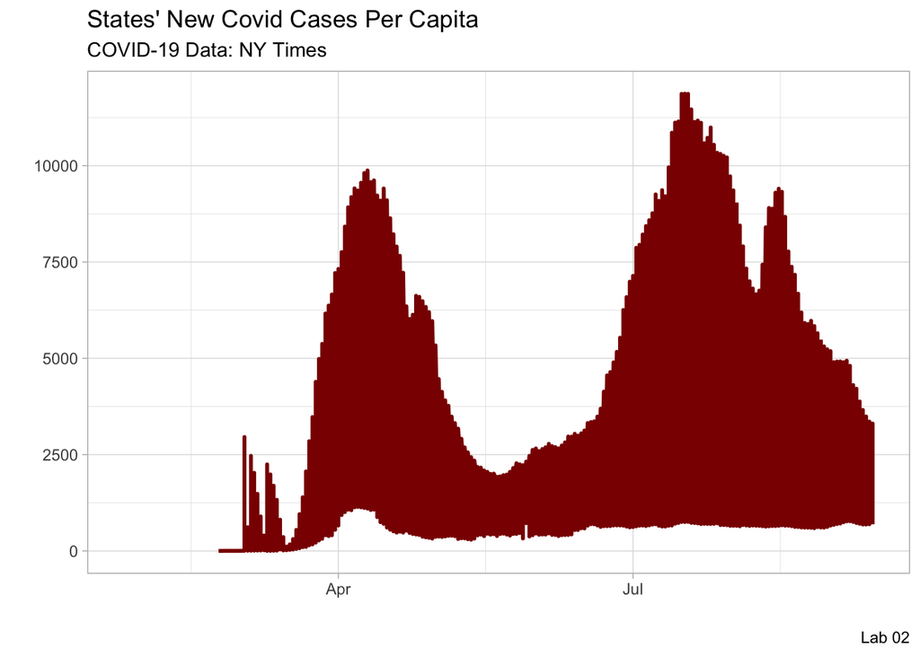

```r
cap_state= PopulationEstimates %>%
  select(state, pop_2019) %>%
  right_join(four_states, by = "state") %>%
  mutate(state_per_cap = ((cases - lag(cases))/ pop_2019),
        seven_day_roll= zoo::rollmean(daily_new_cases, 7, fill= NA, align= 'right'))


ggplot(cap_state, aes(x=date)) +
  geom_col(aes(y= state_per_cap), col= NA, fill= "#F5B8B5") +
  geom_line(aes(y= seven_day_roll), col= "darkred", size= 1) +
  theme_light() +
  labs(title = "States' New Covid Cases Per Capita", x= "", y= "",  caption = "Lab 02", subtitle = "COVID-19 Data: NY Times" ) +
  theme(legend.position = 'NA')
```

The number of daily, new cases at the state level can be misleading since it doesn’t take into consideration the state’s population. Once population is integrated into the number of cases, it is expect for data to reflect a more accurate representation of which out of the four states (CA, LA, NY, FL) has been affected more by COVID.